# spotify-Copy1

## Spotify-soittolistan tarkastelua

Tämän projektin tarkoituksena on harjoitella datan siivoamista sekä tarkastella Spotify-soittolistan dataa havainnollistavien tunnuslukujen (keskiarvo, korrelaatiot) ja kategorisoinnin avulla.

Data on haettu Kagglesta ja sisältää Spotify-soittolistatietoa esimerkiksi kappaleiden tempoista, kestoista, koetusta energisyydestä ja tanssittavuudesta. Tässä projektissa fokuksenani on tutkia muuttujien välisiä yhteyksiä esimerkiksi korrelaatioiden avulla, ja pyrin hahmottamaan miten kappaleiden erilaiset ominaisuudet vaikuttavat esimerkiksi siihen miten ne saavat kuuntelijan kokemaan ne tanssittaviksi.

Tässä projektissa keskeisiä opittuja asioita:

- datan hakeminen APIn avulla
- datan siivoaminen : nan-ja tyhjät arvot, etenkin duplikaatit, ääriarvojen poisto
- visualisointi : seaborn/ matplotlib (korrelaatiot, boxplot, lineaarinen regressio)

```python
import kaggle
```

```python
import pandas as pd
```

```python
import seaborn as sns
```

```python
import zipfile
```

```python
import matplotlib.pyplot as plt
```

### Ladataan data Kaggle-Rest APIsta

```python
!kaggle datasets download -d gauthamvijayaraj/spotify-tracks-dataset-updated-every-week
```

```
Dataset URL: https://www.kaggle.com/datasets/gauthamvijayaraj/spotify-tracks-dataset-updated-every-week
License(s): apache-2.0
spotify-tracks-dataset-updated-every-week.zip: Skipping, found more recently modified local copy (use --force to force download)
```

Alkuperäinen data on zip-muodossa, joten puretaan pakattu kansio ja avataan se dataframessa.

```python
with zipfile.ZipFile('spotify-tracks-dataset-updated-every-week.zip', 'r') as zip:
    zip.extractall('spotify_data')
df = pd.read_csv('spotify_data/spotify_tracks.csv')
df.head()
```

|  | track_id | track_name | artist_name | year | popularity | artwork_url | album_name | acousticness | danceability | duration_ms | ... | key | liveness | loudness | mode | speechiness | tempo | time_signature | valence | track_url | language |
| --- | --- | --- | --- | --- | --- | --- | --- | --- | --- | --- | --- | --- | --- | --- | --- | --- | --- | --- | --- | --- | --- |
| 0 | 2r0ROhr7pRN4MXDMT1fEmd | Leo Das Entry (From "Leo") | Anirudh Ravichander | 2024 | 59 | https://i.scdn.co/image/ab67616d0000b273ce9c65... | Leo Das Entry (From "Leo") | 0.0241 | 0.753 | 97297.0 | ... | 8.0 | 0.1000 | -5.994 | 0.0 | 0.1030 | 110.997 | 4.0 | 0.459 | https://open.spotify.com/track/2r0ROhr7pRN4MXD... | Tamil |
| 1 | 4I38e6Dg52a2o2a8i5Q5PW | AAO KILLELLE | Anirudh Ravichander, Pravin Mani, Vaishali Sri... | 2024 | 47 | https://i.scdn.co/image/ab67616d0000b273be1b03... | AAO KILLELLE | 0.0851 | 0.780 | 207369.0 | ... | 10.0 | 0.0951 | -5.674 | 0.0 | 0.0952 | 164.995 | 3.0 | 0.821 | https://open.spotify.com/track/4I38e6Dg52a2o2a... | Tamil |
| 2 | 59NoiRhnom3lTeRFaBzOev | Mayakiriye Sirikiriye - Orchestral EDM | Anirudh Ravichander, Anivee, Alvin Bruno | 2024 | 35 | https://i.scdn.co/image/ab67616d0000b27334a1dd... | Mayakiriye Sirikiriye (Orchestral EDM) | 0.0311 | 0.457 | 82551.0 | ... | 2.0 | 0.0831 | -8.937 | 0.0 | 0.1530 | 169.996 | 4.0 | 0.598 | https://open.spotify.com/track/59NoiRhnom3lTeR... | Tamil |
| 3 | 5uUqRQd385pvLxC8JX3tXn | Scene Ah Scene Ah - Experimental EDM Mix | Anirudh Ravichander, Bharath Sankar, Kabilan, ... | 2024 | 24 | https://i.scdn.co/image/ab67616d0000b27332e623... | Scene Ah Scene Ah (Experimental EDM Mix) | 0.2270 | 0.718 | 115831.0 | ... | 7.0 | 0.1240 | -11.104 | 1.0 | 0.4450 | 169.996 | 4.0 | 0.362 | https://open.spotify.com/track/5uUqRQd385pvLxC... | Tamil |
| 4 | 1KaBRg2xgNeCljmyxBH1mo | Gundellonaa X I Am A Disco Dancer - Mashup | Anirudh Ravichander, Benny Dayal, Leon James, ... | 2024 | 22 | https://i.scdn.co/image/ab67616d0000b2735a59b6... | Gundellonaa X I Am a Disco Dancer (Mashup) | 0.0153 | 0.689 | 129621.0 | ... | 7.0 | 0.3450 | -9.637 | 1.0 | 0.1580 | 128.961 | 4.0 | 0.593 | https://open.spotify.com/track/1KaBRg2xgNeCljm... | Tamil |

5 rows × 22 columns

Kopioidaan alkuperäinen df uuteen datakehykseen ja poistetaan samalla turhat sararakkeet.

```python
df2 = df.drop(['track_id', 'track_url', 'artwork_url'], axis=1).copy()
```

Dataframen sisältämä data näyttäisi olevan null-arvojen ja datatyyppien osalta kunnossa.

```python
df2.info()
```

```
<class 'pandas.core.frame.DataFrame'>
RangeIndex: 62317 entries, 0 to 62316
Data columns (total 19 columns):
 #   Column            Non-Null Count  Dtype
---  ------            --------------  -----
 0   track_name        62317 non-null  object
 1   artist_name       62317 non-null  object
 2   year              62317 non-null  int64
 3   popularity        62317 non-null  int64
 4   album_name        62317 non-null  object
 5   acousticness      62317 non-null  float64
 6   danceability      62317 non-null  float64
 7   duration_ms       62317 non-null  float64
 8   energy            62317 non-null  float64
 9   instrumentalness  62317 non-null  float64
 10  key               62317 non-null  float64
 11  liveness          62317 non-null  float64
 12  loudness          62317 non-null  float64
 13  mode              62317 non-null  float64
 14  speechiness       62317 non-null  float64
 15  tempo             62317 non-null  float64
 16  time_signature    62317 non-null  float64
 17  valence           62317 non-null  float64
 18  language          62317 non-null  object
dtypes: float64(13), int64(2), object(4)
memory usage: 9.0+ MB
```

```python
df2.isna().sum()
```

```
track_name          0
artist_name         0
year                0
popularity          0
album_name          0
acousticness        0
danceability        0
duration_ms         0
energy              0
instrumentalness    0
key                 0
liveness            0
loudness            0
mode                0
speechiness         0
tempo               0
time_signature      0
valence             0
language            0
dtype: int64
```

### Duplikaattien siivoaminen

Näyttäisi siltä, että dataframesta löytyy duplikaatteja (True 159), siispä poistetaan ne.

```python
df2.duplicated().value_counts()
```

```
False    62158
True       159
Name: count, dtype: int64
```

```python
df2 = df2.drop_duplicates()
```

```python
df2.duplicated().value_counts()
```

```
False    62158
Name: count, dtype: int64
```

Tarkastetaan vielä löytyykö päällekkäisyyksiä saraketasolla. Otetaan tarkasteluun kappaleen nimi -sarake, josta näemme löytyykö toistoa.

```python
df2[df2.duplicated(subset=['track_name'])]
```

|  | track_name | artist_name | year | popularity | album_name | acousticness | danceability | duration_ms | energy | instrumentalness | key | liveness | loudness | mode | speechiness | tempo | time_signature | valence | language |
| --- | --- | --- | --- | --- | --- | --- | --- | --- | --- | --- | --- | --- | --- | --- | --- | --- | --- | --- | --- |
| 28 | Not Ramaiya Vastavaiya (From "Jawan") | Anirudh Ravichander, Sreerama Chandra, Rakshit... | 2024 | 0 | Tollywood Relaxation Radio | 0.02830 | 0.703 | 202556.0 | 0.907 | 0.000001 | 10.0 | 0.301 | -5.157 | 0.0 | 0.0616 | 99.687 | 1.0 | 0.263 | Tamil |
| 29 | Hayyoda (From "Jawan") | Anirudh Ravichander, Priya Mali | 2024 | 0 | Moonlit Melodies Valentine's Day Special | 0.49700 | 0.576 | 200142.0 | 0.841 | 0.005590 | 0.0 | 0.178 | -5.428 | 1.0 | 0.0773 | 95.149 | 4.0 | 0.457 | Tamil |
| 30 | Not Ramaiya Vastavaiya (From "Jawan") | Anirudh Ravichander, Sreerama Chandra, Rakshit... | 2024 | 0 | Holi Non Stop Dhamaka Hits | 0.02830 | 0.703 | 202556.0 | 0.907 | 0.000001 | 10.0 | 0.301 | -5.157 | 0.0 | 0.0616 | 99.687 | 1.0 | 0.263 | Tamil |
| 33 | Vandha Edam (From "Jawan") | Anirudh Ravichander | 2024 | 0 | 2023 Rewind Hits | 0.00543 | 0.653 | 252800.0 | 0.898 | 0.000007 | 1.0 | 0.110 | -5.070 | 1.0 | 0.1670 | 150.034 | 4.0 | 0.299 | Tamil |
| 34 | Hayyoda (From "Jawan") | Anirudh Ravichander, Priya Mali | 2024 | 0 | Sankranti Special Evergreen Superhit Songs | 0.49700 | 0.576 | 200142.0 | 0.841 | 0.005590 | 0.0 | 0.178 | -5.428 | 1.0 | 0.0773 | 95.149 | 4.0 | 0.457 | Tamil |
| ... | ... | ... | ... | ... | ... | ... | ... | ... | ... | ... | ... | ... | ... | ... | ... | ... | ... | ... | ... |
| 62273 | Pattasa (From "Jawan") | Nakash Aziz, Jonita Gandhi, Arivu | 2024 | 0 | Sweet Melodies Of Kollywood | 0.18800 | 0.574 | 195231.0 | 0.883 | 0.000002 | 7.0 | 0.329 | -5.713 | 1.0 | 0.2150 | 123.932 | 4.0 | 0.818 | Tamil |
| 62282 | Aagaya Thamarai | ofRO, Asal Kolaar | 2024 | 25 | Aagaya Thamarai | 0.52400 | 0.604 | 193912.0 | 0.620 | 0.000124 | 2.0 | 0.160 | -7.254 | 1.0 | 0.0695 | 126.433 | 4.0 | 0.291 | Tamil |
| 62288 | Kotha Raja | Jakes Bejoy, Asal Kolaar, Dabzee, Roll Rida, R... | 2023 | 40 | King of Kotha (Tamil) [Original Motion Picture... | 0.17200 | 0.555 | 273231.0 | 0.786 | 0.000042 | 1.0 | 0.108 | -7.431 | 0.0 | 0.1360 | 130.078 | 4.0 | 0.373 | Tamil |
| 62294 | Kotha Raja | Jakes Bejoy, Asal Kolaar, Dabzee, Roll Rida, R... | 2023 | 26 | King of Kotha (Telugu) [Original Motion Pictur... | 0.17200 | 0.555 | 273231.0 | 0.786 | 0.000042 | 1.0 | 0.108 | -7.431 | 0.0 | 0.1360 | 130.078 | 4.0 | 0.373 | Tamil |
| 62301 | Soodam Karpooram - From "Soppana Sundari" | Anthony Daasan, Asal Kolaar, Ajmal Tahseen | 2023 | 0 | Soppana Sundari (Original Motion Picture Sound... | 0.08790 | 0.642 | 175500.0 | 0.939 | 0.000006 | 4.0 | 0.108 | -5.616 | 0.0 | 0.2790 | 153.055 | 4.0 | 0.582 | Tamil |

20637 rows × 19 columns

Kuten huomasimme, duplikaatteja löytyy kappale-sarakeessa mitä selittää albumi-sarake - sama kappale voi olla useammalla kokoelma-albumilla. Tähän viittaa myös pikainen tarkastus: kopioiksi laskettavia nimikkeitä löytyy yli 20000.

```python
df2['track_name'].duplicated().value_counts()
```

```
track_name
False    41521
True     20637
Name: count, dtype: int64
```

Poistetaan sarakkeesta duplikaatit ja tehdään uusi tarkastus:

```python
df2 = df2.drop_duplicates(subset=['track_name'])
```

```python
df2['track_name'].duplicated().value_counts()
```

```
track_name
False    41521
Name: count, dtype: int64
```

```python
df2.duplicated().sum()
```

```
0
```

Tarkastetaan vielä löytyykö rivejä, joiden numeromuotoiset sarakkeet saavat summaksi nollan. Tuloksen mukaan näitä rivejä ei löydy. Alustetaan vielä indeksi ja siirrymme analyysiin.

```python
numeric_columns = df2.select_dtypes(include=['number']).columns
df2[df2[numeric_columns].sum(axis=1)== 0]
```

|  | track_name | artist_name | year | popularity | album_name | acousticness | danceability | duration_ms | energy | instrumentalness | key | liveness | loudness | mode | speechiness | tempo | time_signature | valence | language |
| --- | --- | --- | --- | --- | --- | --- | --- | --- | --- | --- | --- | --- | --- | --- | --- | --- | --- | --- | --- |

```python
df2.reset_index(drop=True)
```

|  | track_name | artist_name | year | popularity | album_name | acousticness | danceability | duration_ms | energy | instrumentalness | key | liveness | loudness | mode | speechiness | tempo | time_signature | valence | language |
| --- | --- | --- | --- | --- | --- | --- | --- | --- | --- | --- | --- | --- | --- | --- | --- | --- | --- | --- | --- |
| 0 | Leo Das Entry (From "Leo") | Anirudh Ravichander | 2024 | 59 | Leo Das Entry (From "Leo") | 0.02410 | 0.753 | 97297.0 | 0.970 | 0.055300 | 8.0 | 0.1000 | -5.994 | 0.0 | 0.1030 | 110.997 | 4.0 | 0.459 | Tamil |
| 1 | AAO KILLELLE | Anirudh Ravichander, Pravin Mani, Vaishali Sri... | 2024 | 47 | AAO KILLELLE | 0.08510 | 0.780 | 207369.0 | 0.793 | 0.000000 | 10.0 | 0.0951 | -5.674 | 0.0 | 0.0952 | 164.995 | 3.0 | 0.821 | Tamil |
| 2 | Mayakiriye Sirikiriye - Orchestral EDM | Anirudh Ravichander, Anivee, Alvin Bruno | 2024 | 35 | Mayakiriye Sirikiriye (Orchestral EDM) | 0.03110 | 0.457 | 82551.0 | 0.491 | 0.000000 | 2.0 | 0.0831 | -8.937 | 0.0 | 0.1530 | 169.996 | 4.0 | 0.598 | Tamil |
| 3 | Scene Ah Scene Ah - Experimental EDM Mix | Anirudh Ravichander, Bharath Sankar, Kabilan, ... | 2024 | 24 | Scene Ah Scene Ah (Experimental EDM Mix) | 0.22700 | 0.718 | 115831.0 | 0.630 | 0.000727 | 7.0 | 0.1240 | -11.104 | 1.0 | 0.4450 | 169.996 | 4.0 | 0.362 | Tamil |
| 4 | Gundellonaa X I Am A Disco Dancer - Mashup | Anirudh Ravichander, Benny Dayal, Leon James, ... | 2024 | 22 | Gundellonaa X I Am a Disco Dancer (Mashup) | 0.01530 | 0.689 | 129621.0 | 0.748 | 0.000001 | 7.0 | 0.3450 | -9.637 | 1.0 | 0.1580 | 128.961 | 4.0 | 0.593 | Tamil |
| ... | ... | ... | ... | ... | ... | ... | ... | ... | ... | ... | ... | ... | ... | ... | ... | ... | ... | ... | ... |
| 41516 | Sani - G.O.A.T Remix | Arvind Raj, Sheezay, Music Kitchen, FSPROD Vin... | 2021 | 30 | Sani (G.O.A.T Remix) | 0.08490 | 0.877 | 359718.0 | 0.469 | 0.000000 | 7.0 | 0.1100 | -11.458 | 1.0 | 0.3530 | 100.024 | 4.0 | 0.504 | Tamil |
| 41517 | Life of Bachelor | A H Kaashif, Navakkarai Naveen Prabanjam, Asal... | 2021 | 30 | Bachelor (Original Motion Picture Soundtrack) | 0.07880 | 0.833 | 154364.0 | 0.689 | 0.000000 | 8.0 | 0.2670 | -5.061 | 1.0 | 0.0813 | 110.041 | 4.0 | 0.524 | Tamil |
| 41518 | Yo Baby | Rakesh Ambigapathy, Asal Kolaar, MC Vickey | 2021 | 18 | Yo Baby | 0.00918 | 0.842 | 234000.0 | 0.765 | 0.000000 | 7.0 | 0.0790 | -5.855 | 1.0 | 0.1370 | 122.038 | 4.0 | 0.669 | Tamil |
| 41519 | Fast Fast Vadiley | Asal Kolaar, Priyadarshan Balasubramanian | 2021 | 1 | Arjuna Phalguna | 0.10100 | 0.682 | 180807.0 | 0.861 | 0.000000 | 1.0 | 0.3200 | -6.061 | 1.0 | 0.2850 | 74.993 | 4.0 | 0.439 | Tamil |
| 41520 | Moonu Moonu Moonu (From "3:33") | Harshavardhan Rameshwar, G. V. Prakash, Dharma... | 2021 | 1 | Moonu Moonu Moonu (From "3:33") | 0.18600 | 0.817 | 202667.0 | 0.903 | 0.000083 | 6.0 | 0.3780 | -7.353 | 0.0 | 0.1170 | 89.975 | 4.0 | 0.837 | Tamil |

41521 rows × 19 columns

## Tarkastellaan tunnuslukuja ja kaavioita

Vilkaistaanpa keskeisiä tunnuslukuja.

Aineisto kattaa dataa vuodesta 1970-luvulta asti. Keskimääräinen tempo on suht normi, 118.

```python
df2.describe()
```

|  | year | popularity | acousticness | danceability | duration_ms | energy | instrumentalness | key | liveness | loudness | mode | speechiness | tempo | time_signature | valence |
| --- | --- | --- | --- | --- | --- | --- | --- | --- | --- | --- | --- | --- | --- | --- | --- |
| count | 41521.000000 | 41521.000000 | 41521.000000 | 41521.000000 | 4.152100e+04 | 41521.000000 | 41521.000000 | 41521.000000 | 41521.000000 | 41521.000000 | 41521.000000 | 41521.000000 | 41521.000000 | 41521.000000 | 41521.000000 |
| mean | 2013.314973 | 16.744732 | 0.386030 | 0.583150 | 2.386200e+05 | 0.581726 | 0.188996 | 5.134318 | 0.196258 | -74.681650 | 0.581393 | 0.093281 | 118.080771 | 3.838178 | 0.480051 |
| std | 10.337078 | 18.854716 | 0.321121 | 0.195265 | 1.252236e+05 | 0.259115 | 0.340106 | 3.557902 | 0.177369 | 2549.007512 | 0.494653 | 0.130155 | 28.883915 | 0.535037 | 0.273958 |
| min | 1971.000000 | 0.000000 | -1.000000 | -1.000000 | 5.000000e+03 | -1.000000 | -1.000000 | -1.000000 | -1.000000 | -100000.000000 | -1.000000 | -1.000000 | -1.000000 | -1.000000 | -1.000000 |
| 25% | 2009.000000 | 0.000000 | 0.080600 | 0.474000 | 1.833470e+05 | 0.402000 | 0.000000 | 2.000000 | 0.093600 | -11.885000 | 0.000000 | 0.037000 | 95.576000 | 4.000000 | 0.260000 |
| 50% | 2016.000000 | 9.000000 | 0.325000 | 0.620000 | 2.349470e+05 | 0.616000 | 0.000083 | 5.000000 | 0.125000 | -8.091000 | 1.000000 | 0.049500 | 118.019000 | 4.000000 | 0.490000 |
| 75% | 2021.000000 | 29.000000 | 0.671000 | 0.724000 | 2.863200e+05 | 0.796000 | 0.153000 | 8.000000 | 0.243000 | -5.721000 | 1.000000 | 0.091400 | 135.882000 | 4.000000 | 0.706000 |
| max | 2024.000000 | 93.000000 | 0.996000 | 0.986000 | 4.581483e+06 | 1.000000 | 0.999000 | 11.000000 | 0.998000 | 1.233000 | 1.000000 | 0.959000 | 239.970000 | 5.000000 | 0.995000 |

Katsotaan miten paljon biisejä on julkaistu listan sisältämän ajanjakson aikana aina 1970-luvulta lähtien. Luodaan kategoriat eri vuosikymmenille ja havainnollistetaan tuloksia laskentakaavion avulla.

```python
bins=[1970,1979,1989,1999,2009,2019,2029]
labels=['70-luku','80-luku','90-luku','2000-luku','2010-luku','2020-luku']
df2['Release_Year'] = pd.cut(df2['year'], bins=bins, labels=labels, right=False)
```

Kuten huomaamme, biisejä on jukaistu kiihtyvällä tahdilla, piikkinä 2010-20 -luku.

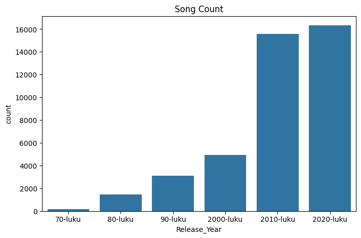

```python
plt.figure(figsize=(8,5))
sns.countplot(df2,x='Release_Year')
plt.title('Song Count')
plt.show()
```

Alla on määritelty ylä- ja alakvartiilien mukaan ääriarvot, jotka poistetaan dataframesta (df2).

```python
Q1 = df2['loudness'].quantile(0.25)
Q3 = df2['loudness'].quantile(0.75)

IQR = Q3 - Q1

lower_threshold = Q1 - 1.5 * IQR
higher_threshold = Q3 + 1.5 * IQR

df2_outliers_cleaned = df2[(df2['loudness'] >= lower_threshold) & (df2['loudness'] <= higher_threshold)]
```

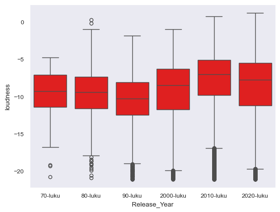

```python
sns.set_style('dark')
sns.set_context('paper')

sns.boxplot(data=df2_outliers_cleaned, x='Release_Year', y='loudness', color='red')
plt.show()
```

Tarkastellaan korrelaatioita muuttujien välillä kokonaiskuvan saamiseksi. Poistetaan nyt ääriarvot kaikista numeerisista sarakkeista:

```python
columns_to_clean = ['popularity', 'acousticness', 'danceability', 'duration_ms','energy',
                   'instrumentalness','liveness','loudness','speechiness','valence','duration_sec']

outlier_mask = pd.Series(True, index=df2.index)

for column in columns_to_clean:
    Q1 = df2[column].quantile(0.25)
    Q3 = df2[column].quantile(0.75)

    IQR = Q3 - Q1

    lower_threshold = Q1 - 1.5 * IQR
    higher_threshold = Q3 + 1.5 * IQR

    outlier_mask &= (df2[column] >= lower_threshold) & (df2[column] <= higher_threshold)

outliers_cleaned = df2[outlier_mask]
```

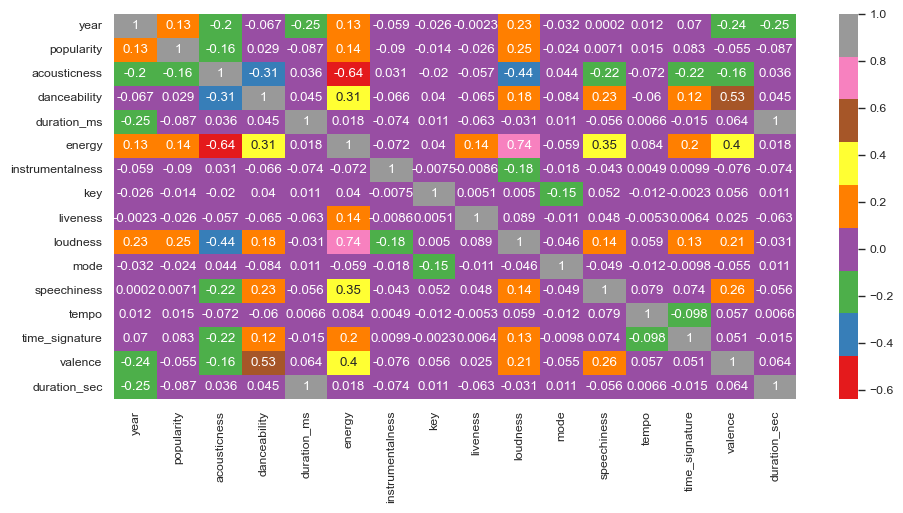

```python
plt.figure(figsize=(11,5))
riippuvuus = outliers_cleaned.corr(numeric_only = True)

sns.heatmap(riippuvuus, annot=True, cmap='Set1')
plt.show()
```

Yllä kaaviossa näemme esimerkiksi vahvat positiiviset yhteydet äänen kovuuden (loudness) ja energisyyden välillä (0.74). Toisaalta, energisyys on suht selkeässä yhteydessä myös valenssiin (0.4), jolla puolestaan on selkeä yhteys tanssittavuuteen (0.53).

Lopuksi katsotaan valenssin ja tanssittavuuden välistä korrelaatiota lineaarisen regressiokaavion avulla. Järjestetään datakehys kappaleiden suosion mukaan tuhannen parhaimman mukaan.

Mitä positiivisemman tunteen kappale saa aikaiseksi, sitä todennäköisemmin se saa tanssimaan.

```python
df3 = outliers_cleaned.sort_values(by='popularity', ascending=False).iloc[:1000].copy()
```

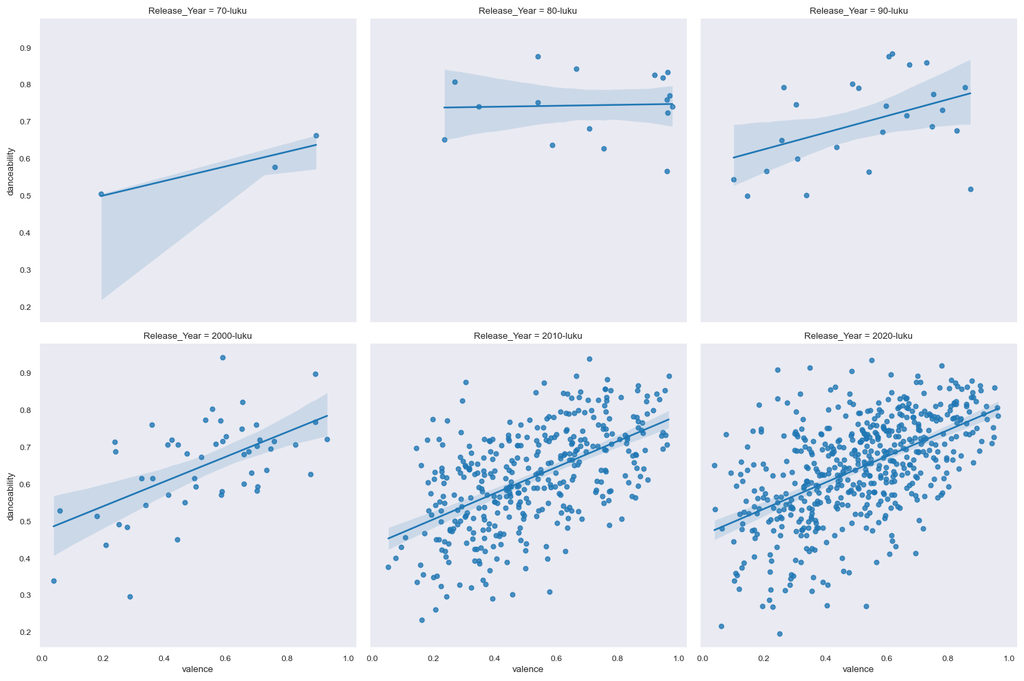

```python
sns.lmplot(data=df3, x='valence', y='danceability', col='Release_Year',col_wrap=3)
plt.show()
```